# Practical Machine Learning-Data Science Specialization

Coursera Student

21 August 2014

# PREPROCESSING DATA

```r
dim(training)
```

```
## [1] 19622   160
```

```r
dim(test)
```

```
## [1]  20 160
```

#### Are variable names unique?

```r
sum(table(names(training)))
```

```
## [1] 160
```

```r
sum(table(unique(names(training))))
```

```
## [1] 160
```

```r
sum(table(names(test)))
```

```
## [1] 160
```

```r
sum(table(unique(names(test))))
```

```
## [1] 160
```

#### Do training and test variable names match?

```r
table(names(training)==names(test))
```

```
##
## FALSE  TRUE
##     1   159
```

```r
names(training)[names(training)!=names(test)]
```

```
## [1] "classe"
```

```r
names(test)[names(test)!=names(training)]
```

```
## [1] "problem_id"
```

#### Are there missing values?

```r
getNa <- function(dfrm) lapply(dfrm, function(x) length(which(is.na(x) =="TRUE")))
g <- getNa(training)
# g[g!=0]
# length(g[g!=0])
g1 <- getNa(test)
# g1[g1!=0]
# length(g1[g1!=0])
```

There are 67 variables with missing values in the training set. Exactly 19216 rows are missing values from all of these variables. There are 100 variables with missing values in the test set. All 20 rows are missing values from all of these variables.

#### Do names of variables missing in training and test tally?

```r
table(names(g1[g1!=0]) %in% names(g[g!=0]))
```

[output not shown]

Decided to remove all 100 variables from analyses. 67 variables are missing in all or majority of cases in both training and test. If there was more data in these, imputation would be attempted. Remaining 33 variables that are missing in test cannot be included since predictions cannot be made on test with these.

#### Creating new training set by removing variables with missing values.

#### Removing first column containing row numbers and last with outcome, “classe”.

#### Converting “user_name” and “cvtd_timestamp” to numeric factors

```r
n <- names(g1[g1!=0])
remnames <- names(training)[!(names(training) %in% n)]
newtrain <- training[,intersect(names(training),remnames)]
dim(newtrain)
```

```
## [1] 19622    60
```

```r
newtrain <- newtrain[,-c(1,60)]
fac <- newtrain[,c(1,4)]
fac[,1] <- as.numeric(fac[,1])
fac[,2] <- as.numeric(fac[,2])
fac[,1] <- as.factor(fac[,1])
fac[,2] <- as.factor(fac[,2])
summary(fac)
```

```
##  user_name cvtd_timestamp
##  1:3892    16     : 1498
##  2:3112    10     : 1497
##  3:3536    19     : 1440
##  4:3070    11     : 1425
##  5:3402    6      : 1380
##  6:2610    3      : 1375
##            (Other):11007
```

```r
newtrain <- newtrain[,-c(1,4)]
newtrain <- cbind(fac, newtrain)
dim(newtrain)
```

```
## [1] 19622    58
```

#### Filtering out variables with near zero variance

```r
library(caret)
nzv <- nearZeroVar(newtrain)
filtnewtrain <- newtrain[,-nzv]
dim(filtnewtrain)
```

```
## [1] 19622    57
```

The variable new_window is removed by the near zero variance filter of caret package.

#### Converting data frame to numeric matrix

#### Applying correlation filter - remove variables with correlation > 0.90

```r
fil <- sapply(filtnewtrain, as.numeric)
corfil <- cor(fil)
f <- findCorrelation(corfil)
fil2 <- fil[,-f]
vars_to_remove <- setdiff(colnames(fil), colnames(fil2))
```

#### Subsetting same variables in test data and making new test set

```r
filtest <- test[,names(test)%in% colnames(fil2)]
dim(filtest)
```

```
## [1] 20 50
```

```r
filtest <- sapply(filtest, as.numeric)
```

#### Centering and scaling training and test data after removing “user_name” variable

#### Adding back “user_name” for both and “classe” for training data

#### Converting to data frame; “user_name”, “classe” and “cvtd_timestamp” to factors

```r
preProcVal <- preProcess(fil2[,-1], method=c("center", "scale"))
trainF <- predict(preProcVal, fil2[,-1])
trainF <- cbind(fil2[,1], trainF)
colnames(trainF)[1:2] <- c("classe", "user_name")
trainF <- data.frame(trainF)
trainF[,1] <- as.factor(as.character(trainF[,1]))
trainF[,2] <- as.factor(as.character(trainF[,2]))
date <- strptime(training$cvtd_timestamp, "%d/%m/%Y %H:%M")
date <- as.factor(as.character(date))
trainF[,3] <- date
testF <- predict(preProcVal, filtest[,-1])
testF <- cbind(filtest[,1], testF)
colnames(testF)[1] <- "user_name"
testF <- data.frame(testF)
testF[,1] <- as.factor(as.character(testF[,1]))
date <- strptime(test$cvtd_timestamp, "%d/%m/%Y %H:%M")
date <- as.factor(as.character(date))
testF[,4] <- date
```

## EXPLORATORY ANALYSIS

library(caret)

#### Timestamp

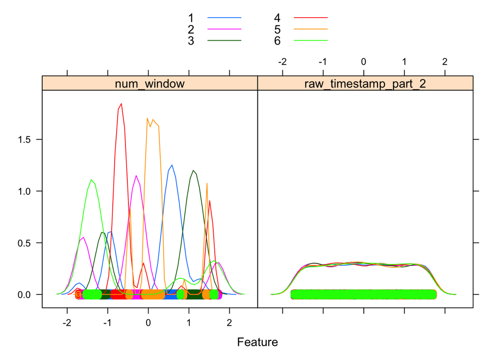

```r
featurePlot( x = trainF[,4:5],
             y = trainF$classe,
             plot = "density",
            auto.key = list(columns = 2))
```

#### Variables related to belt and arm

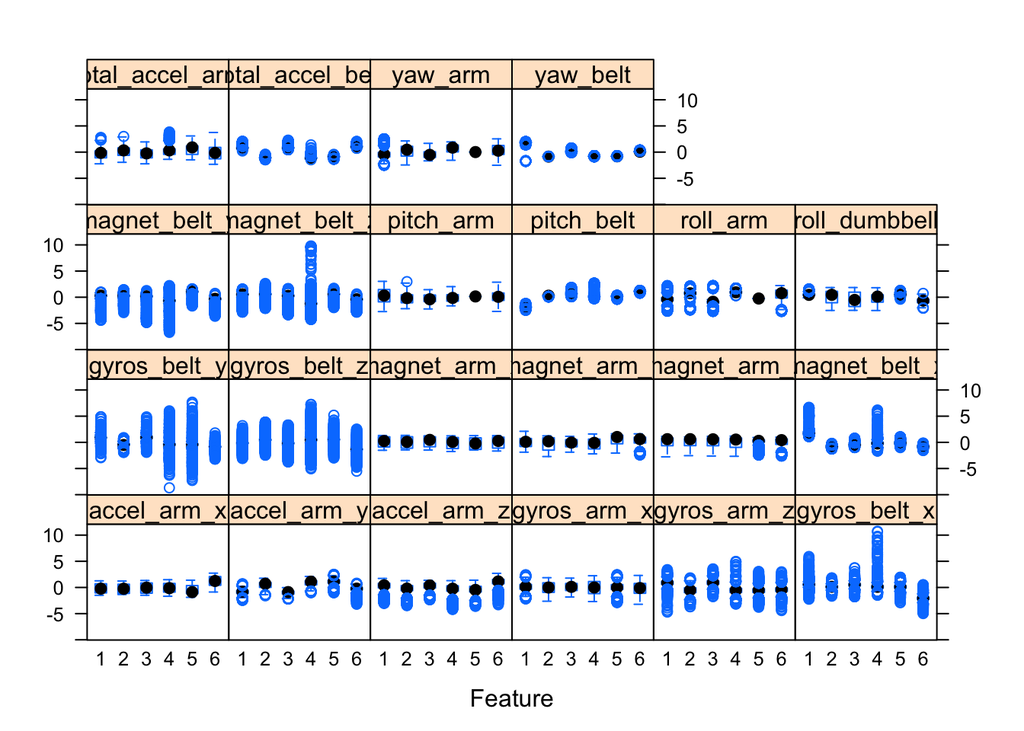

```r
featurePlot( x = trainF[,6:27],
             y = trainF$classe,
             plot = "box",
             auto.key = list(columns = 2))
```

#### Variables related to dumbell

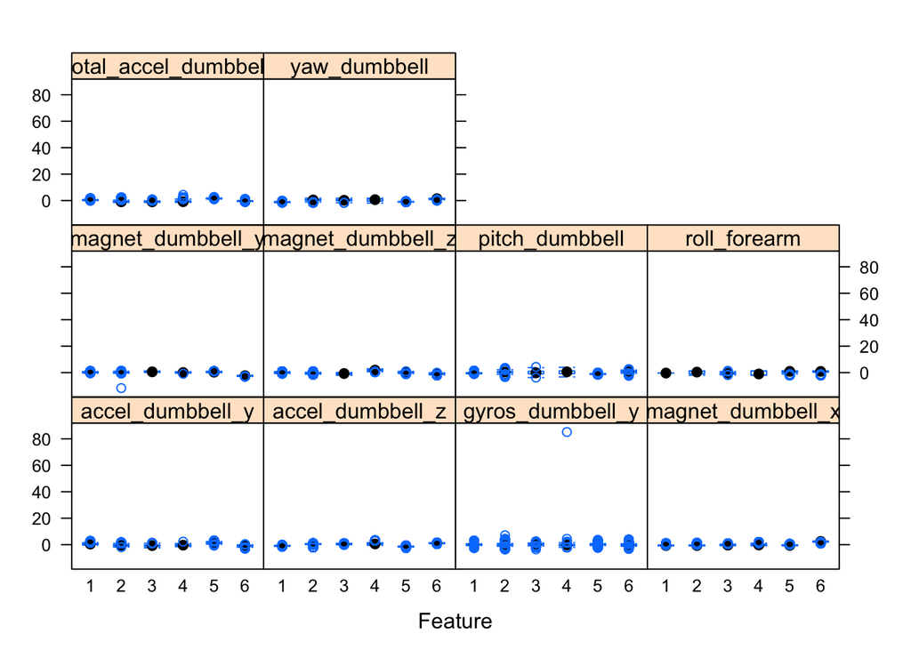

```r
featurePlot( x = trainF[,c(28:31, 34:39)],
             y = trainF$classe,
             plot = "box",
            auto.key = list(columns = 2))
```

#### Variables related to forearm

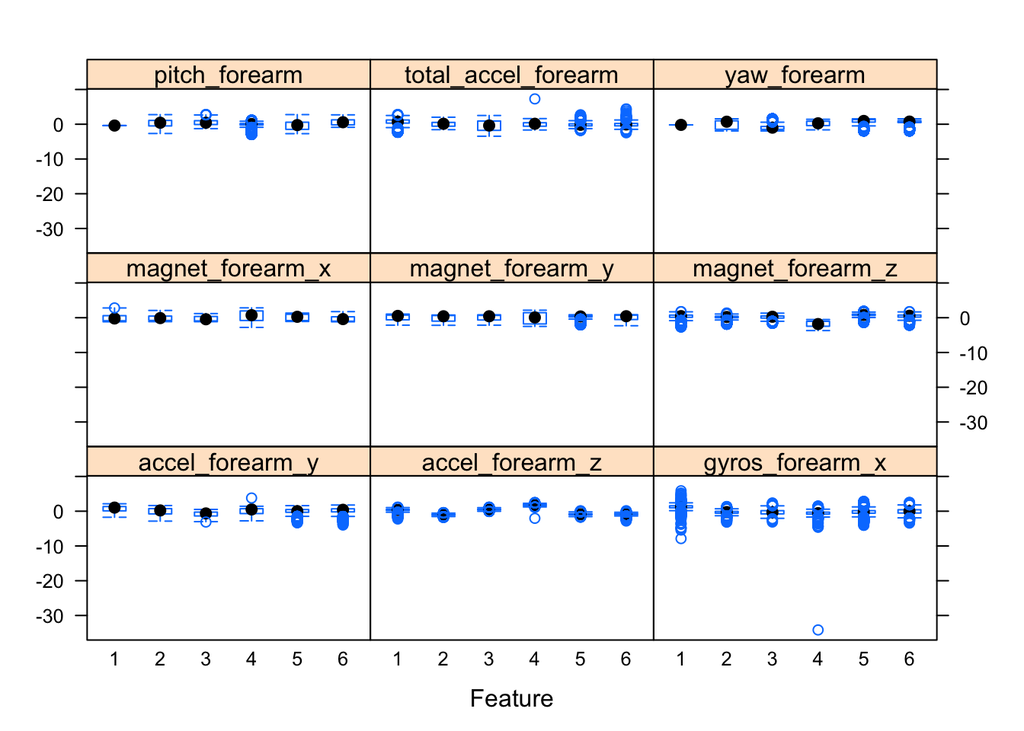

```r
featurePlot( x = trainF[,c(40:43,46:50)],
             y = trainF$classe,
             plot = "box",
             auto.key = list(columns = 2))
```

#### outliers in gyros_forearm_x and gyros_forearm_y, gyros_dumbell_y, gyros_dumbell_z

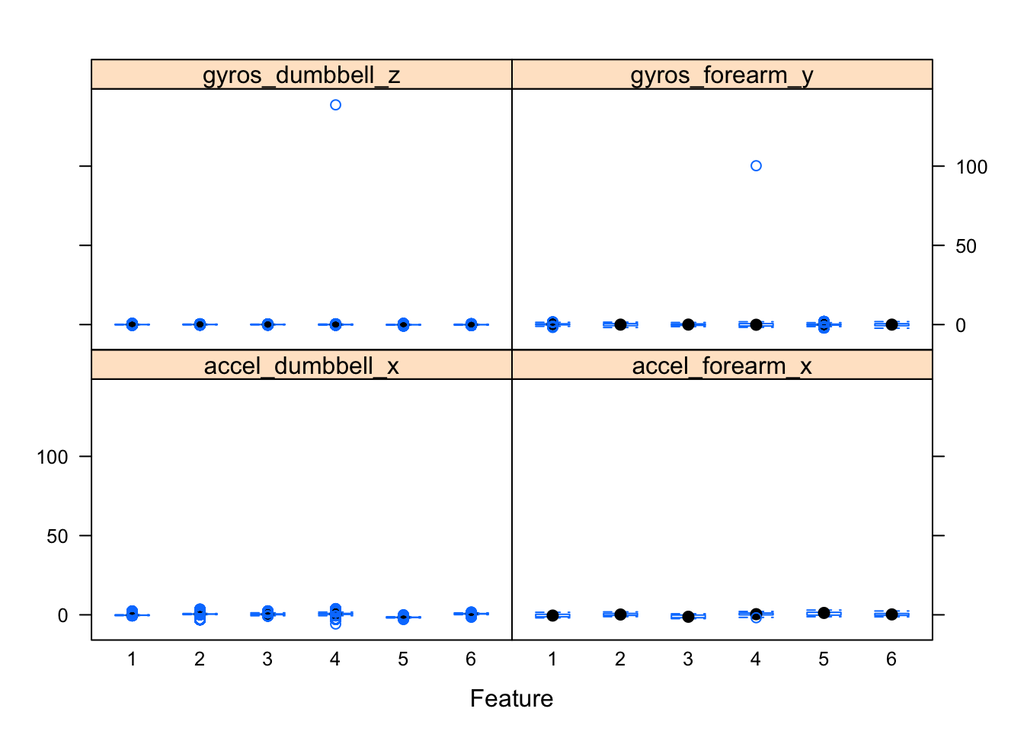

```r
featurePlot( x = trainF[,c(32,33,44,45)],
             y = trainF$classe,
             plot = "box",
             auto.key = list(columns = 2))
```

Single points are pulling up scale on y-axis to 100. Need to impute these values to median.

#### Pick out single extreme outliers and replace by median

```r
summary(trainF[,c(32,33,44,45)])
```

```
##  gyros_dumbbell_z accel_dumbbell_x gyros_forearm_y  accel_forearm_x
##  Min.   : -0.98   Min.   :-5.799   Min.   : -2.29   Min.   :-2.4162
##  1st Qu.: -0.08   1st Qu.:-0.318   1st Qu.: -0.50   1st Qu.:-0.6443
##  Median :  0.00   Median : 0.306   Median : -0.01   Median : 0.0258
##  Mean   :  0.00   Mean   : 0.000   Mean   :  0.00   Mean   : 0.0000
##  3rd Qu.:  0.07   3rd Qu.: 0.588   3rd Qu.:  0.50   3rd Qu.: 0.7622
##  Max.   :138.69   Max.   : 3.916   Max.   :100.27   Max.   : 2.9827
```

```r
w <- which(trainF$gyros_dumbbell_y > 80)
trainF$gyros_dumbbell_y[w] <- median(trainF$gyros_dumbbell_y)
w2 <- which(trainF$gyros_dumbbell_z > 100)
trainF$gyros_dumbbell_z[w2] <- median(trainF$gyros_dumbbell_z)
w3 <- which(abs(trainF$gyros_forearm_x) > 30)
trainF$gyros_forearm_x[w3] <- median(trainF$gyros_forearm_x)
w4 <- which(trainF$gyros_forearm_y > 99)
trainF$gyros_forearm_y[w4] <- median(trainF$gyros_forearm_y)
summary(trainF[,c(32,33,44,45)])
```

```
##  gyros_dumbbell_z  accel_dumbbell_x gyros_forearm_y   accel_forearm_x
##  Min.   :-0.9844   Min.   :-5.799   Min.   :-2.2882   Min.   :-2.4162
##  1st Qu.:-0.0792   1st Qu.:-0.318   1st Qu.:-0.4951   1st Qu.:-0.6443
##  Median :-0.0004   Median : 0.306   Median :-0.0146   Median : 0.0258
##  Mean   :-0.0071   Mean   : 0.000   Mean   :-0.0051   Mean   : 0.0000
##  3rd Qu.: 0.0695   3rd Qu.: 0.588   3rd Qu.: 0.4982   3rd Qu.: 0.7622
##  Max.   : 0.8742   Max.   : 3.916   Max.   : 1.9527   Max.   : 2.9827
```

#### replacing numeric with original “classe”

```r
trainF$classe <- training$classe
```

## BUILDING THE MODEL

#### Splitting original training set into subtraining and internal test set

```r
library(caret)
set.seed(1234)
ind <- createDataPartition(trainF$classe, p=0.7, list=F)
subtrain <- trainF[ind,]
subtest <- trainF[-ind,]
```

#### Building the model : Random Forest with crossvalidation

```r
library(doMC)
registerDoMC(cores = 5)
fitControl <- trainControl(method = "repeatedcv", number = 10, repeats = 10)
set.seed(1234)
rfFit <- train(classe~., data = subtrain, method = "rf",
trControl = fitControl, verbose= FALSE)
```

#### The model object

```
Random Forest

13737 samples
   50 predictor
    5 classes: 'A', 'B', 'C', 'D', 'E'

No pre-processing
Resampling: Cross-Validated (10 fold, repeated 10 times)

Summary of sample sizes: 12365, 12363, 12364, 12364, 12362, 12362, ...

Resampling results across tuning parameters:

  mtry  Accuracy  Kappa  Accuracy SD  Kappa SD
   2    0.985     0.981  0.003542     0.004484
  37    0.999     0.999  0.000771     0.000975
  72    0.999     0.998  0.000877     0.001109
```

Accuracy was used to select the optimal model using the largest value. The final value used for the model was mtry = 37.

#### Predicting on held out test set belonging to original training data :

```r
predRF <- predict(rfFit, newdata = subtest)
confusionMatrix(predRF, subtest$classe)
```

```
Confusion Matrix and Statistics

          Reference
Prediction    A    B    C    D    E
         A 1673    1    0    0    0
         B    1 1138    1    0    0
         C    0    0 1025    0    0
         D    0    0    0  964    0
         E    0    0    0    0 1082

Overall Statistics

               Accuracy : 0.9995
                 95% CI : (0.9985, 0.9999)
    No Information Rate : 0.2845
    P-Value [Acc > NIR] : < 2.2e-16

                  Kappa : 0.9994
 Mcnemar's Test P-Value : NA

Statistics by Class:

                     Class: A Class: B Class: C Class: D Class: E
Sensitivity            0.9994   0.9991   0.9990   1.0000   1.0000
Specificity            0.9998   0.9996   1.0000   1.0000   1.0000
Pos Pred Value         0.9994   0.9982   1.0000   1.0000   1.0000
Neg Pred Value         0.9998   0.9998   0.9998   1.0000   1.0000
Prevalence             0.2845   0.1935   0.1743   0.1638   0.1839
Detection Rate         0.2843   0.1934   0.1742   0.1638   0.1839
Detection Prevalence   0.2845   0.1937   0.1742   0.1638   0.1839
Balanced Accuracy      0.9996   0.9994   0.9995   1.0000   1.0000
```